# REPORT CONTROL CHECK NL V102

Thijs de Boer

2021

Last update: 2021-02-01 15:10:02

```r
load("C:/Users/Thijs/surfdrive/COVID vaccine/R data/git/NL/NL - control check/.RData")

set_theme(
  base=theme_blank(),
  geom.outline.size = 0.01,
  geom.outline.color = "white",
  geom.label.size = 3,
  geom.label.color = "grey50")
```

# 1 Population

Total number of participants:

```r
df.total %>% filter(error == 0) %>% nrow()
```

```
## [1] 342
```

Number of participants that failed the attention test:

```r
df.total %>% filter(error == 0) %>% nrow() - df.total %>% filter(IMC=="1" & error == 0) %>% nrow()
```

```
## [1] 93
```

Participants between 0-17:

```r
df.total %>% filter(IMC=="1" & age < 18 & error == 0) %>% nrow()
```

```
## [1] 0
```

Percentage of participants who are at least 18 years old and did not fail the IMC:

```r
percent(df.def %>% nrow() / df.total %>% filter(error == 0) %>% nrow())
```

```
## [1] "73%"
```

Number of participants in this analysis:

```r
df.def %>% nrow()
```

```
## [1] 249
```

Number of participants in the final dataset that failed the manipulation check:

```r
df.def %>% nrow() - df.def %>% filter(manipulation.check=="1") %>% nrow()
```

```
## [1] 142
```

Which is:

```r
percent(df.def %>% filter(manipulation.check!="1") %>% nrow() / df.def %>% nrow(), accuracy = 0.01)
```

```
## [1] "57.03%"
```

In more detail:

```r
df.def %>% group_by(Q298, experimental.group) %>% tally()
```

```
## # A tibble: 6 x 3
## # Groups:   Q298 [3]
##    Q298 experimental.group     n
##   <int> <chr>              <int>
## 1     1 advice                29
## 2     1 no text               46
## 3     2 advice                60
## 4     2 no text               48
## 5     3 advice                19
## 6     3 no text               47
```

Q298 is the manipulation check:  
- 1 = independence  
- 2 = advice (correct answer for “advice” condition)  
- 3 = None of these (correct answer for “no text” condition)

# 2 Experiment: Perceived independence of EMA

## 2.1 Randomisation check

This table shows how many respondents are assigned to each experimental group.

```r
df.def %>%
  group_by(experimental.group) %>%
  tally()
```

```
## # A tibble: 2 x 2
##   experimental.group     n
##   <chr>              <int>
## 1 advice               108
## 2 no text              141
```

## 2.2 Description

```r
df.def %>%
sjmisc::descr(perceived.independence.reversed, show = c("n", "NA.prc", "mean", "sd", "md", "iqr", "trimmed", "range", "skew")) %>%
  kbl(digits= 2) %>%
 kable_paper()
```

| var | n | NA.prc | mean | sd | md | trimmed | range | iqr | skew |
| --- | --- | --- | --- | --- | --- | --- | --- | --- | --- |
| perceived.independence.reversed | 249 | 0 | 3.35 | 1.35 | 3 | 3.34 | 6 (1-7) | 2 | 0.13 |

## 2.3 Histogram

### 2.3.1 Without those who received erroneous manipulation check

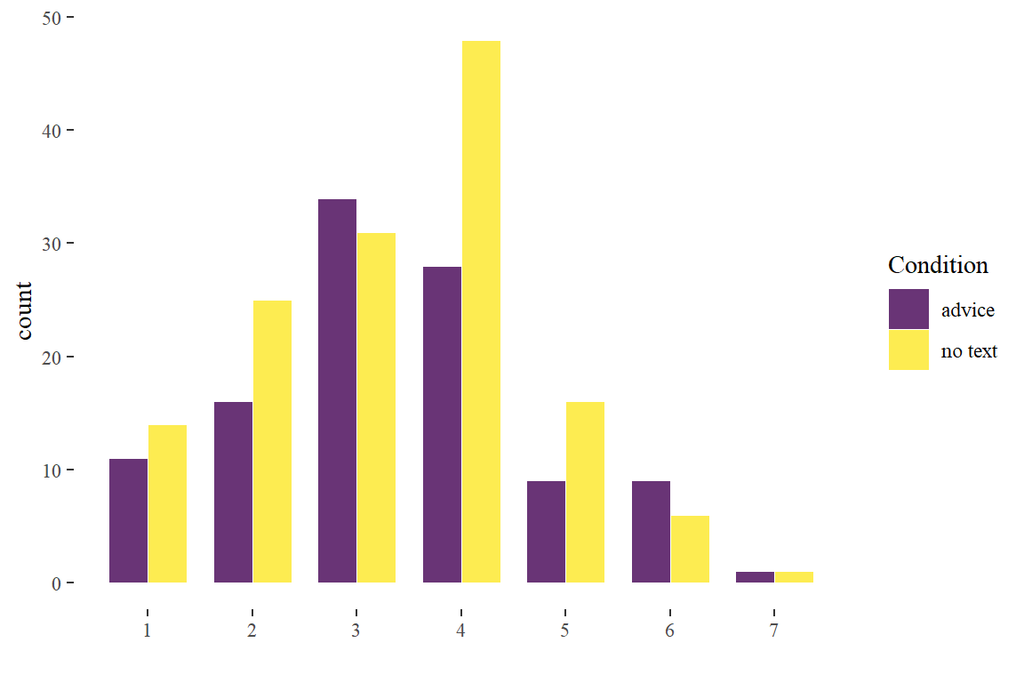

```r
df.def %>%
  ggplot(aes(x = perceived.independence.reversed, fill = experimental.group)) +
  geom_bar(width = 0.75,alpha = 0.8, position = position_dodge()) +
  scale_x_continuous(name="", breaks = 1:7) + scale_fill_manual(name = "Condition") +  scale_fill_viridis_d(name = "Condition") +
  theme_tufte()
```

## 2.4 T-test

### 2.4.1 Without those who received erroneous manipulation check

```r
tadaa_t.test(data = df.def, response = perceived.independence.reversed, group = experimental.group, print = "markdown")
```

Table 1: **Welch Two Sample t-test** with alternative hypothesis: $\mu_1 \neq \mu_2$

| Diff | $\mu_1$ advice | $\mu_2$ no text | t | SE | df | $CI_{95\%}$ | p | Cohen's d |
| --- | --- | --- | --- | --- | --- | --- | --- | --- |
| 0.01 | 3.36 | 3.35 | 0.08 | 0.17 | 224.61 | (-0.33 - 0.36) | .938 | 0.01 |

### 2.4.2 Without those who failed the manipulation check

```r
tadaa_t.test(data = df.check, response = perceived.independence.reversed, group = experimental.group, print = "markdown")
```

Table 2: **Welch Two Sample t-test** with alternative hypothesis: $\mu_1 \neq \mu_2$

| Diff | $\mu_1$ advice | $\mu_2$ no text | t | SE | df | $CI_{95\%}$ | p | Cohen's d |
| --- | --- | --- | --- | --- | --- | --- | --- | --- |
| -0.15 | 3.32 | 3.47 | -0.55 | 0.28 | 103.84 | (-0.7 - 0.4) | .587 | -0.1 |

### 2.4.3 With complete dataset

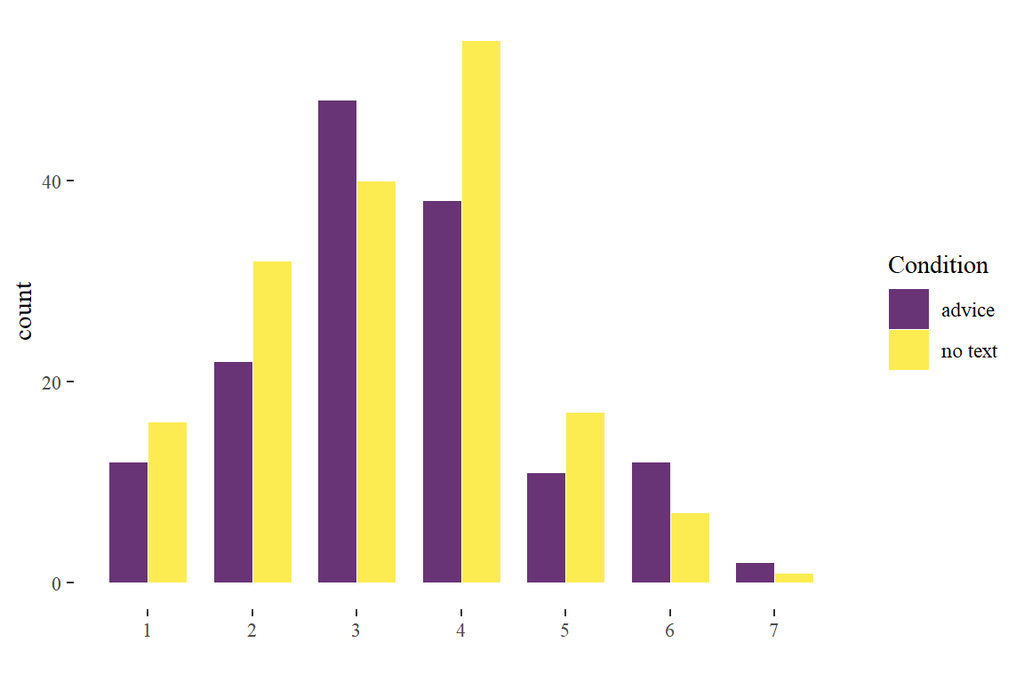

```r
df.def.error %>%
  ggplot(aes(x = perceived.independence.reversed, fill = experimental.group)) +
  geom_bar(width = 0.75,alpha = 0.8, position = position_dodge()) +
  scale_x_continuous(name="", breaks = 1:7) + scale_fill_manual(name = "Condition") +  scale_fill_viridis_d(name = "Condition") +
  theme_tufte()
```

## 2.5 T-test: With complete dataset

```r
tadaa_t.test(data = df.def.error, response = perceived.independence.reversed, group = experimental.group, print = "markdown")
```

Table 3: **Welch Two Sample t-test** with alternative hypothesis: $\mu_1 \neq \mu_2$

| Diff | $\mu_1$ no text | $\mu_2$ advice | t | SE | df | $CI_{95\%}$ | p | Cohen's d |
| --- | --- | --- | --- | --- | --- | --- | --- | --- |
| -0.11 | 3.29 | 3.4 | -0.7 | 0.15 | 299.47 | (-0.41 - 0.19) | .483 | -0.08 |

# 3 Credbility

## 3.1 Description

```r
df.def %>%
sjmisc::descr(credibility.index, show = c("n", "NA.prc", "mean", "sd", "md", "iqr", "trimmed", "range", "skew")) %>%
  kbl(digits= 2) %>%
 kable_paper()
```

| var | n | NA.prc | mean | sd | md | trimmed | range | iqr | skew |
| --- | --- | --- | --- | --- | --- | --- | --- | --- | --- |
| credibility.index | 249 | 0 | 4.53 | 1.1 | 4.5 | 4.55 | 5.5 (1.5-7) | 1.17 | -0.15 |

## 3.2 Histogram: Without those who received erroneous manipulation check

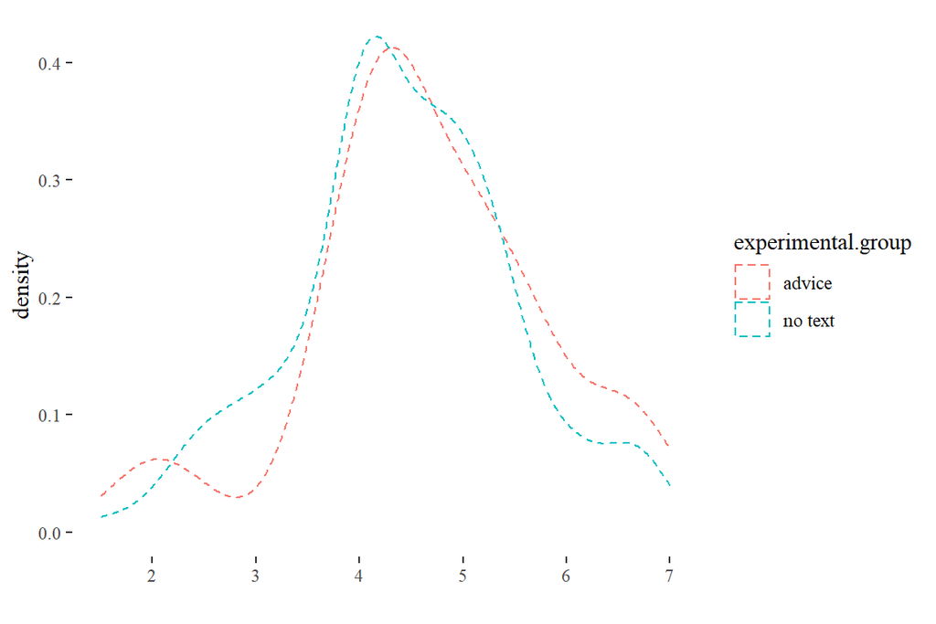

```r
df.def %>% ggplot(aes(x= credibility.index, color = experimental.group)) +
 geom_density(alpha= .1, linetype= "dashed") + labs(x = "Credibility index") + theme(axis.title.y = element_blank()) +
  scale_x_continuous(name="", breaks = 1:7) + scale_fill_manual(name = "Condition") +  scale_fill_viridis_d(name = "Condition") +
  theme_tufte()
```

## 3.3 T-test

### 3.3.1 Without those who received erroneous manipulation check

```r
tadaa_t.test(data = df.def, response = credibility.index, group = experimental.group, print = "markdown")
```

Table 4: **Welch Two Sample t-test** with alternative hypothesis: $\mu_1 \neq \mu_2$

| Diff | $\mu_1$ advice | $\mu_2$ no text | t | SE | df | $CI_{95\%}$ | p | Cohen's d |
| --- | --- | --- | --- | --- | --- | --- | --- | --- |
| 0.22 | 4.66 | 4.44 | 1.58 | 0.14 | 219.55 | (-0.06 - 0.51) | .116 | 0.2 |

### 3.3.2 With those who failed the manipulation check filtered out

```r
tadaa_t.test(data = df.check, response = credibility.index, group = experimental.group, print = "markdown")
```

Table 5: **Welch Two Sample t-test** with alternative hypothesis: $\mu_1 \neq \mu_2$

| Diff | $\mu_1$ advice | $\mu_2$ no text | t | SE | df | $CI_{95\%}$ | p | Cohen's d |
| --- | --- | --- | --- | --- | --- | --- | --- | --- |
| 0.32 | 4.71 | 4.4 | 1.27 | 0.25 | 97.45 | (-0.18 - 0.81) | .207 | 0.25 |

## 3.4 Histogram: Complete dataset

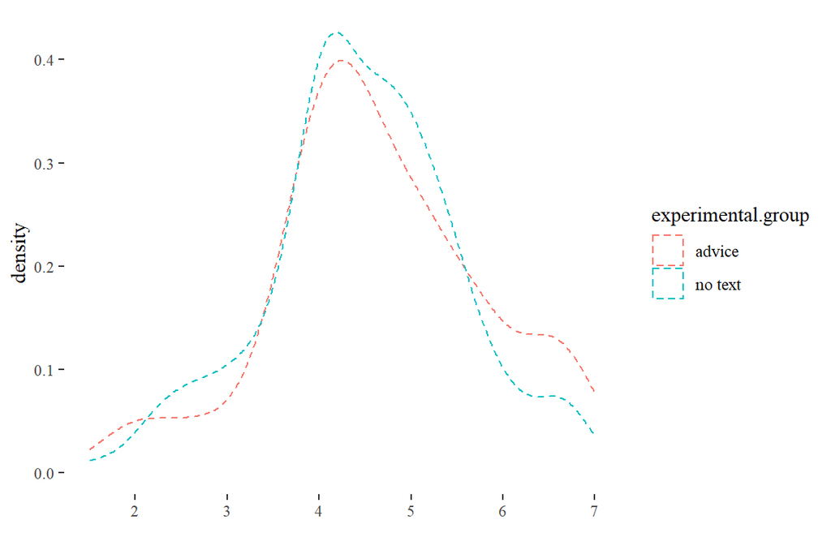

```r
df.def.error %>% ggplot(aes(x= credibility.index, color = experimental.group)) +
 geom_density(alpha= .1, linetype= "dashed") + labs(x = "Credibility index") + theme(axis.title.y = element_blank()) +
  scale_x_continuous(name="", breaks = 1:7) + scale_fill_manual(name = "Condition") +  scale_fill_viridis_d(name = "Condition") +
  theme_tufte()
```

## 3.5 T-test: Complete dataset

```r
tadaa_t.test(data = df.def.error, response = credibility.index, group = experimental.group, print = "markdown")
```

Table 6: **Welch Two Sample t-test** with alternative hypothesis: $\mu_1 \neq \mu_2$

| Diff | $\mu_1$ no text | $\mu_2$ advice | t | SE | df | $CI_{95\%}$ | p | Cohen's d |
| --- | --- | --- | --- | --- | --- | --- | --- | --- |
| -0.16 | 4.48 | 4.64 | -1.31 | 0.13 | 290.52 | (-0.41 - 0.08) | .193 | -0.15 |

# 4 Time

## 4.1 Survey duration

### 4.1.1 Histogram

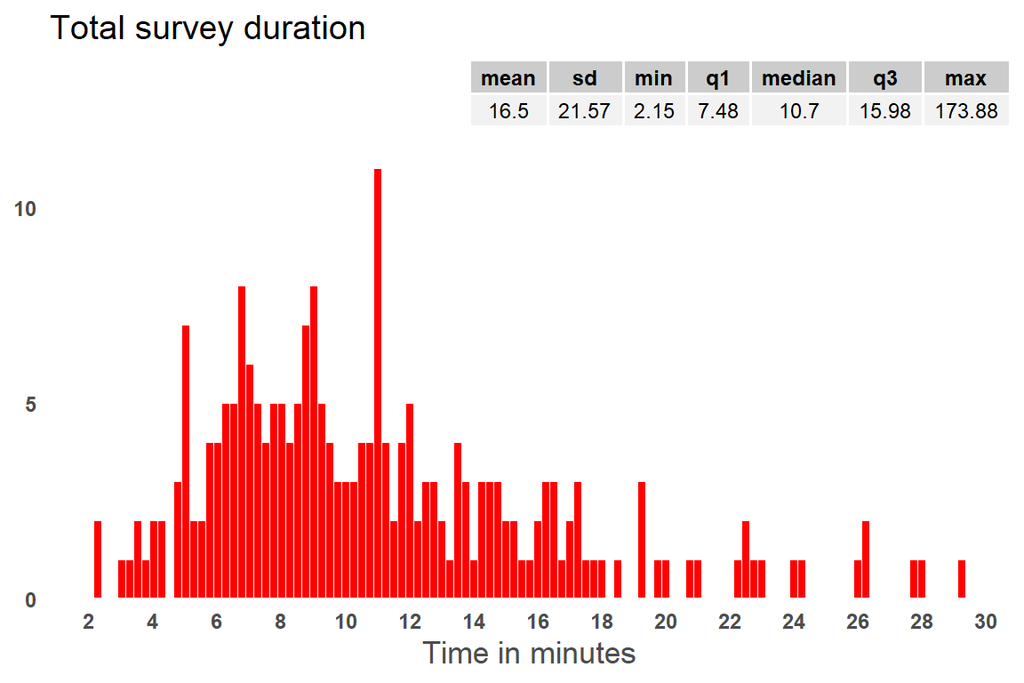

```r
df.def %>% filter(duration < 30) %>%
plot_frq((duration),
        geom.colors = alpha("red",0.8),
        type = "hist",
        geom.size = 0.25) +
  theme(axis.text = element_text(face = "bold",  size= 9)) + labs(title = "Total survey duration") +  scale_x_continuous(name="Time in minutes", breaks = seq(0,30, 2)) + scale_y_continuous(expand = expansion(c(0, 0.25))) + annotate(geom = "table", x = Inf, y = Inf, label = list(table.duration))
```

## 4.2 Do participants read the information about the case?

### 4.2.1 Page submission - introduction of case

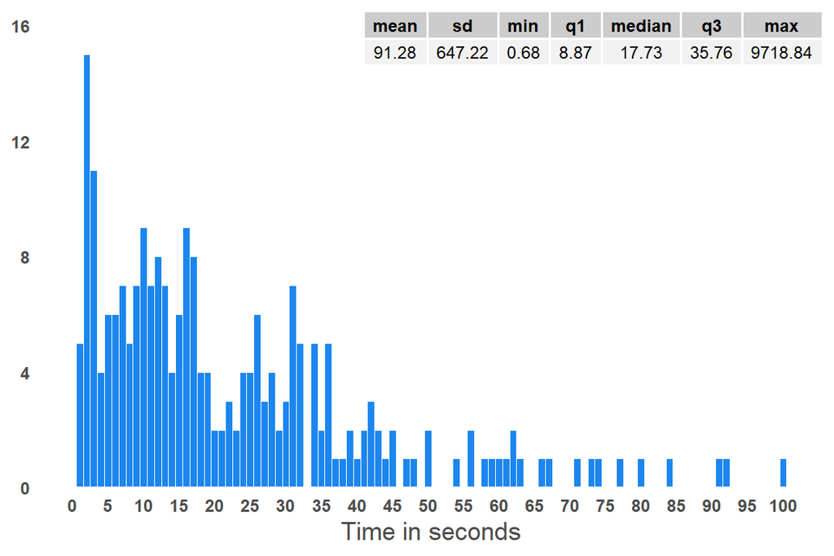

```r
df.def %>% filter(intro.submit < 100) %>%
plot_frq((intro.submit),
        geom.colors = alpha("dodgerblue2",0.8),
        type = "hist",
        geom.size = 1) +
  theme(axis.text = element_text(face = "bold",  size= 9)) +
  scale_x_continuous(name="Time in seconds",breaks = seq(0,100,5)) + scale_y_continuous(expand = expansion(c(0, 0.1))) + annotate(geom = "table", x = Inf, y = Inf, label = list(table.intro.submit))
```

### 4.2.2 Page submission - EMA’s decision

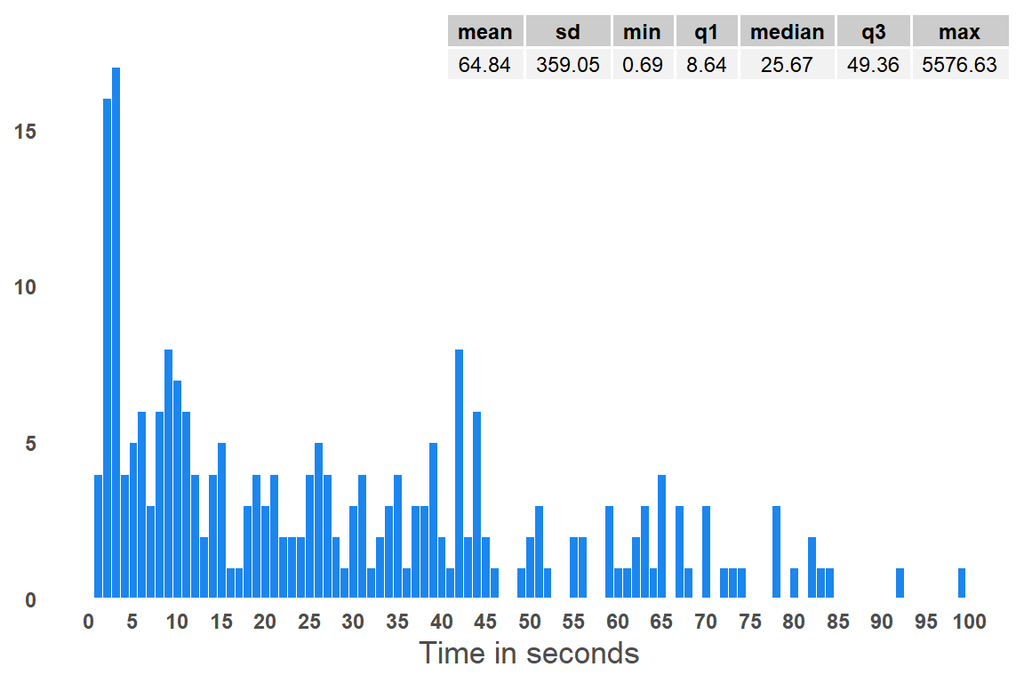

```r
df.def %>% filter(decision.submit < 100) %>%
plot_frq((decision.submit),
        geom.colors = alpha("dodgerblue2",0.8),
        type = "hist",
        geom.size = 1) +
  theme(axis.text = element_text(face = "bold",  size= 9)) +
  scale_x_continuous(name= "Time in seconds", breaks = seq(0,100,5)) + scale_y_continuous(expand = expansion(c(0, 0.1))) + annotate(geom = "table", x = Inf, y = Inf, label = list(table.decision.submit))
```

## 4.3 Time and …

### 4.3.1 …experimental groups

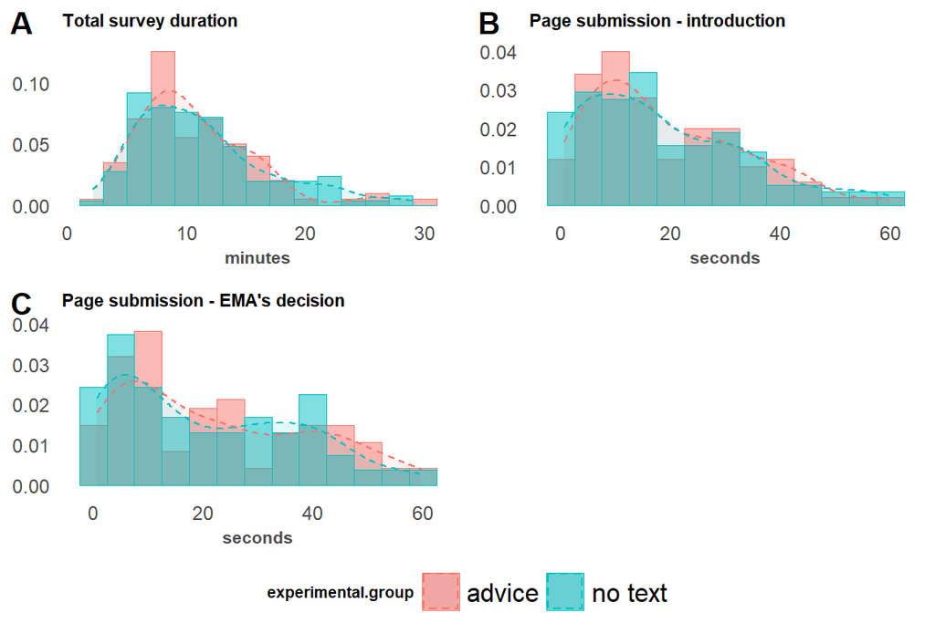

```r
p5 <- df.def %>% filter(duration < 30) %>% ggplot(aes(x= duration, color = experimental.group, fill = experimental.group)) + geom_histogram(aes(y=..density..), alpha=0.5, position="identity", binwidth = 2) +
 geom_density(alpha= .1, linetype= "dashed") + labs(title = "Total survey duration", x = "minutes") + theme(axis.title.y = element_blank(), title = element_text(size = 7, face = "bold"),  axis.text = element_text(size = 9))

p6  <- df.def %>% filter(intro.submit < 60) %>% ggplot(aes(x= intro.submit, color = experimental.group, fill = experimental.group)) + geom_histogram(aes(y=..density..), alpha=0.5, position="identity", binwidth = 5) +
 geom_density(alpha= .1, linetype= "dashed") + labs(title = "Page submission - introduction", x = "seconds") + theme(axis.title.y = element_blank(), title = element_text(size = 7, face = "bold"),  axis.text = element_text(size = 9))

p8 <- df.def %>% filter(decision.submit < 60) %>% ggplot(aes(x=decision.submit, color = experimental.group, fill = experimental.group)) +
 geom_histogram(aes(y=..density..), alpha=0.5, position="identity", binwidth = 5) +
 geom_density(alpha= .1, linetype= "dashed") + labs(title = "Page submission - EMA's decision", x = "seconds", color = "Manipulation Check") + theme(axis.title.y = element_blank(), title = element_text(size = 7, face = "bold"),  axis.text = element_text(size = 9))

ggarrange(p5, p6, p8, nrow = 2, ncol = 2, labels="AUTO", legend = "bottom", common.legend = TRUE)
```

T-tests (outliers removed - i.e., cases outside 1.5 times the interquartile range):

*Survey duration*

```r
tadaa_t.test(data = out.duration, response = duration, group = experimental.group, print = "markdown")
```

Table 7: **Welch Two Sample t-test** with alternative hypothesis: $\mu_1 \neq \mu_2$

| Diff | $\mu_1$ advice | $\mu_2$ no text | t | SE | df | $CI_{95\%}$ | p | Cohen's d |
| --- | --- | --- | --- | --- | --- | --- | --- | --- |
| -0.71 | 10.53 | 11.24 | -1.04 | 0.68 | 219.9 | (-2.06 - 0.64) | .3 | -0.14 |

*Page submission - Introduction*

```r
tadaa_t.test(data = out.intro.submit, response = intro.submit, group = experimental.group, print = "markdown")
```

Table 8: **Welch Two Sample t-test** with alternative hypothesis: $\mu_1 \neq \mu_2$

| Diff | $\mu_1$ advice | $\mu_2$ no text | t | SE | df | $CI_{95\%}$ | p | Cohen's d |
| --- | --- | --- | --- | --- | --- | --- | --- | --- |
| 0.52 | 21.07 | 20.56 | 0.23 | 2.25 | 218.79 | (-3.91 - 4.94) | .818 | 0.03 |

*Page submission - decision*

```r
tadaa_t.test(data = out.decision.submit, response = decision.submit, group = experimental.group, print = "markdown")
```

Table 9: **Welch Two Sample t-test** with alternative hypothesis: $\mu_1 \neq \mu_2$

| Diff | $\mu_1$ advice | $\mu_2$ no text | t | SE | df | $CI_{95\%}$ | p | Cohen's d |
| --- | --- | --- | --- | --- | --- | --- | --- | --- |
| -1.71 | 28.07 | 29.78 | -0.52 | 3.28 | 221.09 | (-8.17 - 4.75) | .603 | -0.07 |

### 4.3.2 …interface (pc/mobile)

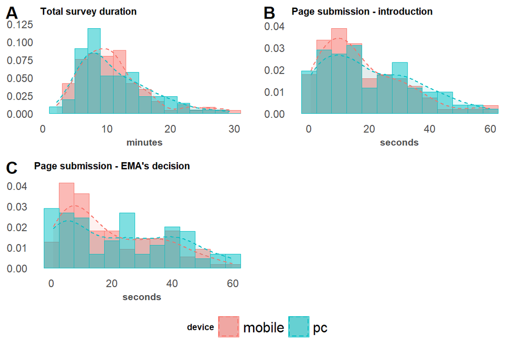

```r
p9 <- df.def %>% filter(duration < 30) %>% ggplot(aes(x= duration, color = device, fill = device)) + geom_histogram(aes(y=..density..), alpha=0.5, position="identity", binwidth = 2) +
 geom_density(alpha= .1, linetype= "dashed") + labs(title = "Total survey duration", x = "minutes") + theme(axis.title.y = element_blank(), title = element_text(size = 7, face = "bold"),  axis.text = element_text(size = 9))

p10 <- df.def %>% filter(intro.submit < 60) %>% ggplot(aes(x= intro.submit, color = device, fill = device)) + geom_histogram(aes(y=..density..), alpha=0.5, position="identity", binwidth = 5) +
 geom_density(alpha= .1, linetype= "dashed") + labs(title = "Page submission - introduction", x = "seconds") + theme(axis.title.y = element_blank(), title = element_text(size = 7, face = "bold"),  axis.text = element_text(size = 9))


p12 <- df.def %>% filter(decision.submit < 60) %>% ggplot(aes(x=decision.submit, color = device, fill = device)) +
 geom_histogram(aes(y=..density..), alpha=0.5, position="identity", binwidth = 5) +
 geom_density(alpha= .1, linetype= "dashed") + labs(title = "Page submission - EMA's decision", x = "seconds", color = "Manipulation Check") + theme(axis.title.y = element_blank(), title = element_text(size = 7, face = "bold"),  axis.text = element_text(size = 9))

ggarrange(p9, p10, p12, nrow = 2, ncol = 2, labels="AUTO", legend = "bottom", common.legend = TRUE)
```